# Assignment 4

## Submit as an HTML file

Print your Emory ID below

```python
2512377
```

```
2512377
```

Import both the MatPlotLib and Numpy libraries

```python
import numpy as np
import matplotlib.pyplot as plt
```

1. For-loops to count conditional statements
- Define a custom list of people's ages  
  (write down ages for 8 people, between ten and fifty)
- Define an empty list called `list_eligible`
- Use a For-Loop that goes through the ages of the 8 people, then appends the  
  value `True` to `list_eligible` if their age is greater than or equal to 16  
  and `False` otherwise

```python
#list of ages for 8 people
list_age = [10, 15, 20 , 25, 30, 35, 40, 45]

#empty list
list_eligible = []
for x in list_age:
    test_age = x >= 16
    list_eligible.append(test_age)

print(list_eligible)
```

```
[False, False, True, True, True, True, True, True]
```

1. This is a follow-up to question 1.
- If you run `np.sum(list_eligible)`, what value is Python assigning to  
  `True` or `False` elements in the sum? Write you answer as a comment.
- How would you use this information to count the amount of people who are  
  **NOT** eligible? Write code that answers this question.

```python
np.sum(list_eligible)
#python assigns a 0 to False, and 1 to true in the sum.
#python assigns 6 to this
list_ineligible = []
for x in list_age:
    #counts for people not over the age of 16
    not_age = x < 16
    list_ineligible.append(not_age)
np.sum(list_ineligible)

#2 people are ineligible
```

```
2
```

1. Use a For-Loop for message automation
- Write your own list of customer names
- Print an automated message with the unique name of the customer that tells  
  them they've won a giveaway
- How many messages to do you expect to see? Write code that automatically  
  prints the size of the customer list

```python
# Write your own code
customer_list = ["Jamie", "Jay", "John"]

index = 0
for customer in customer_list:
    print("Congratulations, you've won a giveaway, " + customer + "!")
    index = index + 1

print(index)
print(len(customer_list))
```

```
Congratulations, you've won a giveaway, Jamie!
Congratulations, you've won a giveaway, Jay!
Congratulations, you've won a giveaway, John!
3
3
```

1. For-Loops + Plotting
- Create an array of x-values with all the integers between 1 and 10
- Create a vector `vec_y1` where each element is computed from  
  the formula $ y_1 = 0.5x^4 + 2x^2 + 4x$.
- Create a vector `vec_y2` where each element is computed from  
  the formula $ y_2 = 2x^3 + 4x + 4$.
- Create an object `list_vectors` with elements `vec_y1` and `vec_y2`
- Create a for-loop that goes through each element of  
  `list_vectors` and plots each list of $y$ values against $x$

Note: The final output should be a 2 dimensional scatter plot with two sets,  
of points, with the $y_1$ and $y_2$ on the vertical axis, and the $x$ values  
on the horizontal axis. Remember to always label the axes to make it look  
more professional.

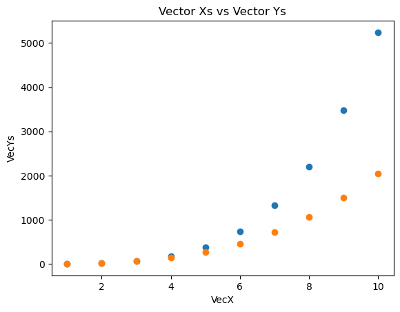

```python
vec_x = np.array([1,2,3,4,5,6,7,8,9,10])

vec_y1 = 0.5* vec_x **4 + 2* vec_x **2 + 4* vec_x

vec_y2 = 2 * vec_x **3 + 4 *vec_x + 4

list_vectors = (vec_y1, vec_y2)

for vec_y in list_vectors:
    plt.scatter(x = vec_x, y = vec_y)

plt.xlabel("VecX")
plt.ylabel("VecYs")
plt.title("Vector Xs vs Vector Ys")
plt.show()
```

1. Loops + Multiple Lists

Before starting, read the following information about nested loops:

https://www.w3schools.com/python/gloss_python_for_nested.asp

[figure not shown]

- Convert the following three lists to arrays

`list_lower = [93, 87, 83, 80, 75, 70, 65, 60, 55, 0]`  
`list_upper = [100,92, 86, 82, 79, 74, 69, 64, 59, 54]`  
`list_letters = ["A","A-","B+","B","B-","C+","C","C-","D","F"]`

- Convert the following list of student grades to an array

`list_studentgrades = [80, 70, 96, 65, 92]`

- Create a nested for-loop that outputs

"The student got a numeric grade of .... and their letter grade was ..."

Example of the procedure:

```python
list_lower = [93, 87, 83, 80, 75, 70, 65, 60, 55, 0]
list_upper = [100,92, 86, 82, 79, 74, 69, 64, 59, 54]
list_letters = ["A","A-","B+","B","B-","C+","C","C-","D","F"]
list_studentgrades = [80, 70, 96, 65, 92]

#converts list to vec
vec_lower = np.array(list_lower)
vec_upper = np.array(list_upper)
vec_letters = np.array(list_letters)
vec_grades = np.array(list_studentgrades)

#for overall loop is only for the elements in list_studentgrades
for grade in list_studentgrades:
    #list created has none for each of the 5 elements
    letter_grade = []
    #for each i in the created range(len)) so i can take the index of [0,1,2,3,etc]
    for i in range(len(list_lower)):
        #if grade is between the elements of the lists, list = that list_letter's index
        if vec_lower[i] <= grade <= vec_upper[i]:
            letter_grade = list_letters[i]
            #if true break into overall for loop and print
            break
    print("The student got a numeric grade of " + str(grade)+ " and their letter grade was " + str(letter_grade))


#or this including numeric grade

for i in vec_grades:
    index = 0
    for n in vec_lower:
        if i >= n:
            letter = vec_letters[index]
        else:
            index = index + 1
    print("The student got a numeric grade of " + str(i)+ " and their letter grade was " + str(letter) )
```

```
The student got a numeric grade of 80 and their letter grade was B
The student got a numeric grade of 70 and their letter grade was C+
The student got a numeric grade of 96 and their letter grade was A
The student got a numeric grade of 65 and their letter grade was C
The student got a numeric grade of 92 and their letter grade was A-
The student got a numeric grade of 80 and their letter grade was B
The student got a numeric grade of 70 and their letter grade was C+
The student got a numeric grade of 96 and their letter grade was A
The student got a numeric grade of 65 and their letter grade was C
The student got a numeric grade of 92 and their letter grade was A-
```